# Chapter 1

# Chapter 1 Data in R

This .rmd file is where you will be doing all of your work this semester. We will generally be following the book *Fundations of Statistics with R*. After each chapter, you will turn in your .rmd file for a grade.

Using RMarkdown is easy. Above you will see a 'Knit' button. Try pressing the `Knit` command and see what happens.

https://media.csuchico.edu/media/Math+350+Chapter+1+Part+1/1_whzfu54r

## Section 1.1 Arithmetic and variable assignment

The following code chunck in R demonstrates how R can be used as a calculator. Click the green arrow on the right to run the code below.

```r
1+1
```

```
## [1] 2
```

```r
4-3
```

```
## [1] 1
```

```r
3*7
```

```
## [1] 21
```

```r
8/3
```

```
## [1] 2.666667
```

```r
2^3
```

```
## [1] 8
```

```r
pi^2
```

```
## [1] 9.869604
```

```r
2*exp(1)
```

```
## [1] 5.436564
```

There are many built in functions in R such as `log` or `exp`. Using these functions in R is not much different than using them on your calculator. The function `log` has two arguements, one is required and one is set to a default, $log_{b}(x)$ where *b* is the base. The default is *b* which is set to `exp(1)` (i.e. the natural logarithm). Below are some examples of built in functions in R.

```r
exp(2)
```

```
## [1] 7.389056
```

```r
log(8)
```

```
## [1] 2.079442
```

```r
log(8,base=2)
```

```
## [1] 3
```

### Storing results

Most of the time we will want to save our results. To do so we use the `<-` notation as shown below:

```r
height <- 62 # in inches
height <- height + 2
height <- 3 * height
```

To see the final value of height above we can either type the word or put the last line in parentheses.

```r
(height <- 3 * height)
```

```
## [1] 576
```

## 1.3 Vectors

A vector is a list of values in order to be able to work with them. For us they will usually represent data collected on a charactertic of the population. In general, we want to give the vector a name so that we can call it later when needed.

```r
##Vector of the first 5 primes
primes_5 <- c(2,3,5,7,11)


##Vector of the numbers 1 through 10
one_ten<- c(1,2,3,4,5,6,7,8,9,10)
one_ten<-1:10
one_ten<-seq(1,10,by=1)

## We can use the "rep" function to repeat a number of sequence of numbers

x<-rep(c(2,3),times=c(2,2))
x #viewing the results
```

```
## [1] 2 2 3 3
```

```r
(y<-rep(c(2, 3), length.out = 3))
```

```
## [1] 2 3 2
```

```r
x<-rep(2,3)
x #viewing the results
```

```
## [1] 2 2 2
```

```r
x<-rep(c(2,3),4)
x #viewing the results
```

```
## [1] 2 3 2 3 2 3 2 3
```

```r
##The vector does not have to be numerical if we use quotes around the word

rep(c("Bryan", "Darrin"), each = 2)# tick marks or quotes will work
```

```
## [1] "Bryan"  "Bryan"  "Darrin" "Darrin"
```

## 1.4 Indexing vectors

https://media.csuchico.edu/media/Math+350+Chapter+1+Part+2/1_q7zivi6q

We can index vectors to pull off values at a particular position on a vector.

```r
##Returns first and second number of the vector we called "primes" above
primes_5 #the entire c vector
```

```
## [1]  2  3  5  7 11
```

```r
primes_5[1] #returns the element at teh first index in vector c
```

```
## [1] 2
```

```r
primes_5[2] #returns the element at eht second index in vector c index start at 1!!!
```

```
## [1] 3
```

```r
##Returns first three numbers of a vector

x<-c(1,2,3,4,5,6) #assigning a vector using C function
x[1:3] #prints the first three elements in the vector x
```

```
## [1] 1 2 3
```

```r
x #prints all the elements in the vector x
```

```
## [1] 1 2 3 4 5 6
```

We can change a vector to TRUE and FALSE.

```r
##first Identify the numbers in primes that are greater than 6

primes_5 #lists all the numbers in the vector
```

```
## [1]  2  3  5  7 11
```

```r
primes_5>6 #R studio goes threw vector c and assigns true or false values based on the element in the vector
```

```
## [1] FALSE FALSE FALSE  TRUE  TRUE
```

```r
as.numeric(primes_5>6)# converts the trues to 1s and false to 0s
```

```
## [1] 0 0 0 1 1
```

```r
## And count the number of primes greater than 6
mean(primes_5>6)
```

```
## [1] 0.4
```

```r
sum(primes_5>6)
```

```
## [1] 2
```

### Built in data sets in R

R comes with many built in data sets such as **rivers**. Rivers contain data on the lengths in miles of 141 major rivers in North America.

```r
## To see the data set

rivers
```

```
##   [1]  735  320  325  392  524  450 1459  135  465  600  330  336  280  315  870
##  [16]  906  202  329  290 1000  600  505 1450  840 1243  890  350  407  286  280
##  [31]  525  720  390  250  327  230  265  850  210  630  260  230  360  730  600
##  [46]  306  390  420  291  710  340  217  281  352  259  250  470  680  570  350
##  [61]  300  560  900  625  332 2348 1171 3710 2315 2533  780  280  410  460  260
##  [76]  255  431  350  760  618  338  981 1306  500  696  605  250  411 1054  735
##  [91]  233  435  490  310  460  383  375 1270  545  445 1885  380  300  380  377
## [106]  425  276  210  800  420  350  360  538 1100 1205  314  237  610  360  540
## [121] 1038  424  310  300  444  301  268  620  215  652  900  525  246  360  529
## [136]  500  720  270  430  671 1770
```

```r
## To see some of the data

head(rivers,n=10)
```

```
##  [1]  735  320  325  392  524  450 1459  135  465  600
```

```r
##Another data set

discoveries
```

```
## Time Series:
## Start = 1860
## End = 1959
## Frequency = 1
##   [1]  5  3  0  2  0  3  2  3  6  1  2  1  2  1  3  3  3  5  2  4  4  0  2  3  7
##  [26] 12  3 10  9  2  3  7  7  2  3  3  6  2  4  3  5  2  2  4  0  4  2  5  2  3
##  [51]  3  6  5  8  3  6  6  0  5  2  2  2  6  3  4  4  2  2  4  7  5  3  3  0  2
##  [76]  2  2  1  3  4  2  2  1  1  1  2  1  4  4  3  2  1  4  1  1  1  0  0  2  0
```

```r
##To make a table of discoveries
table(discoveries)
```

```
## discoveries
##  0  1  2  3  4  5  6  7  8  9 10 12
##  9 12 26 20 12  7  6  4  1  1  1  1
```

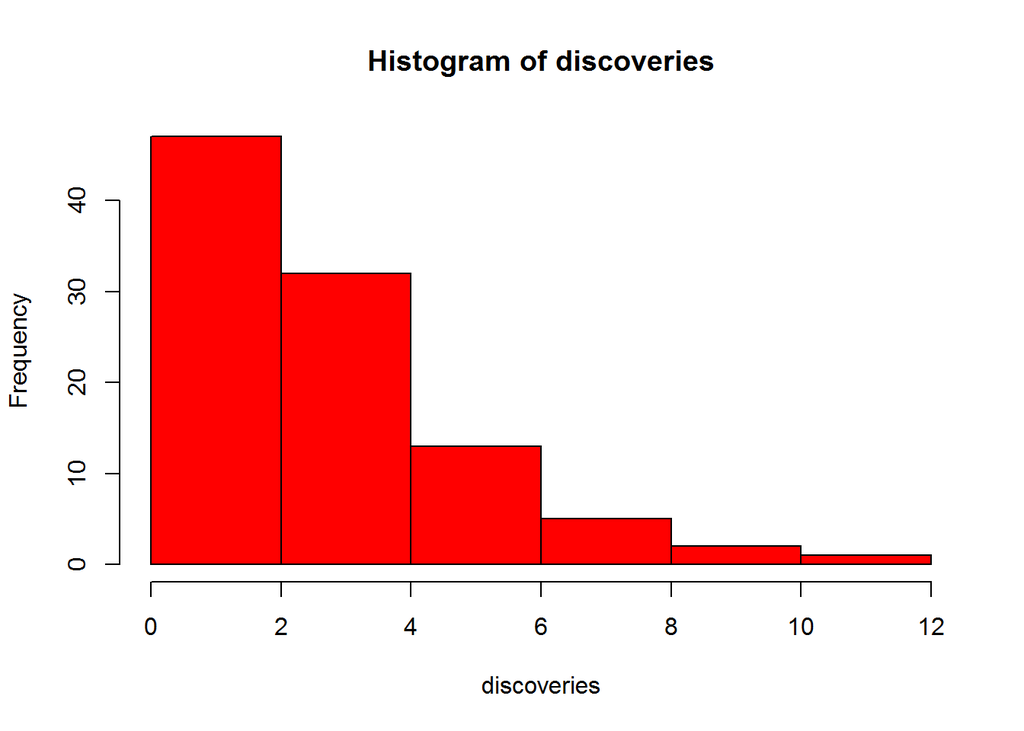

```r
##To make a historgraph of discoveries
hist(discoveries,col="red")
```

## 1.5 Data Types

All data in R has a type such as numeric for real numbers or integer for a variable that is all integers. A character variable refers to a variable where observations are recorded into categories. Read the section in the book to learn about the other types of variables.

### Missing Data

Missing data comes up frequently in data. R denotes a missing value with NA. Let's consider an example using the built in data set `airquality` and the variable `Ozone` which shows the daily Ozone levels (ppb) in New York during the summer of 1973.

```r
airquality$Ozone
```

```
##   [1]  41  36  12  18  NA  28  23  19   8  NA   7  16  11  14  18  14  34   6
##  [19]  30  11   1  11   4  32  NA  NA  NA  23  45 115  37  NA  NA  NA  NA  NA
##  [37]  NA  29  NA  71  39  NA  NA  23  NA  NA  21  37  20  12  13  NA  NA  NA
##  [55]  NA  NA  NA  NA  NA  NA  NA 135  49  32  NA  64  40  77  97  97  85  NA
##  [73]  10  27  NA   7  48  35  61  79  63  16  NA  NA  80 108  20  52  82  50
##  [91]  64  59  39   9  16  78  35  66 122  89 110  NA  NA  44  28  65  NA  22
## [109]  59  23  31  44  21   9  NA  45 168  73  NA  76 118  84  85  96  78  73
## [127]  91  47  32  20  23  21  24  44  21  28   9  13  46  18  13  24  16  13
## [145]  23  36   7  14  30  NA  14  18  20
```

We can see that there are multiple missing values.

Suppose we want to find the average Ozone level. We would use the function **mean** in R like so:

```r
mean(airquality$Ozone) #we have na values that we need to remove default is NA values are counted!
```

```
## [1] NA
```

The mean is the sum of all the values divided by the number of observations. Because of the NAs, R doesn't know how to sum the values. Therefore, we need to tell R that we want to ignore the missing values. The following code lets R know that it can skip any observation with a missing value.

```r
mean(airquality$Ozone,na.rm=TRUE) #we have na values that we need to remove
```

```
## [1] 42.12931
```

The default of the mean function is to include all values. When we type na.rm=TRUE it changes the default so that R knows to remove NAs.

## 1.6 Data Frames

https://media.csuchico.edu/media/Math+350+Chapter+1+Part+3/1_zsrnmvdu

So far we have looked at data that came in single vectors. However, most data have several characteristics (variables) recorded on each observation. Let's consider the built in data file called mtcars consists of 32 observations and 11 variables.

```r
mtcars #displays the values as a vector
```

```
##                      mpg cyl  disp  hp drat    wt  qsec vs am gear carb
## Mazda RX4           21.0   6 160.0 110 3.90 2.620 16.46  0  1    4    4
## Mazda RX4 Wag       21.0   6 160.0 110 3.90 2.875 17.02  0  1    4    4
## Datsun 710          22.8   4 108.0  93 3.85 2.320 18.61  1  1    4    1
## Hornet 4 Drive      21.4   6 258.0 110 3.08 3.215 19.44  1  0    3    1
## Hornet Sportabout   18.7   8 360.0 175 3.15 3.440 17.02  0  0    3    2
## Valiant             18.1   6 225.0 105 2.76 3.460 20.22  1  0    3    1
## Duster 360          14.3   8 360.0 245 3.21 3.570 15.84  0  0    3    4
## Merc 240D           24.4   4 146.7  62 3.69 3.190 20.00  1  0    4    2
## Merc 230            22.8   4 140.8  95 3.92 3.150 22.90  1  0    4    2
## Merc 280            19.2   6 167.6 123 3.92 3.440 18.30  1  0    4    4
## Merc 280C           17.8   6 167.6 123 3.92 3.440 18.90  1  0    4    4
## Merc 450SE          16.4   8 275.8 180 3.07 4.070 17.40  0  0    3    3
## Merc 450SL          17.3   8 275.8 180 3.07 3.730 17.60  0  0    3    3
## Merc 450SLC         15.2   8 275.8 180 3.07 3.780 18.00  0  0    3    3
## Cadillac Fleetwood  10.4   8 472.0 205 2.93 5.250 17.98  0  0    3    4
## Lincoln Continental 10.4   8 460.0 215 3.00 5.424 17.82  0  0    3    4
## Chrysler Imperial   14.7   8 440.0 230 3.23 5.345 17.42  0  0    3    4
## Fiat 128            32.4   4  78.7  66 4.08 2.200 19.47  1  1    4    1
## Honda Civic         30.4   4  75.7  52 4.93 1.615 18.52  1  1    4    2
## Toyota Corolla      33.9   4  71.1  65 4.22 1.835 19.90  1  1    4    1
## Toyota Corona       21.5   4 120.1  97 3.70 2.465 20.01  1  0    3    1
## Dodge Challenger    15.5   8 318.0 150 2.76 3.520 16.87  0  0    3    2
## AMC Javelin         15.2   8 304.0 150 3.15 3.435 17.30  0  0    3    2
## Camaro Z28          13.3   8 350.0 245 3.73 3.840 15.41  0  0    3    4
## Pontiac Firebird    19.2   8 400.0 175 3.08 3.845 17.05  0  0    3    2
## Fiat X1-9           27.3   4  79.0  66 4.08 1.935 18.90  1  1    4    1
## Porsche 914-2       26.0   4 120.3  91 4.43 2.140 16.70  0  1    5    2
## Lotus Europa        30.4   4  95.1 113 3.77 1.513 16.90  1  1    5    2
## Ford Pantera L      15.8   8 351.0 264 4.22 3.170 14.50  0  1    5    4
## Ferrari Dino        19.7   6 145.0 175 3.62 2.770 15.50  0  1    5    6
## Maserati Bora       15.0   8 301.0 335 3.54 3.570 14.60  0  1    5    8
## Volvo 142E          21.4   4 121.0 109 4.11 2.780 18.60  1  1    4    2
```

```r
View(mtcars) #displays as a table
?mtcars #if you have any questions use the ? to explore
```

```
## starting httpd help server ... done
```

Before we start to play with the data we should find out more information about it. We might want to know how many observations (in this case cars) are in the data set and what characteristics (variables) have been collected on each car.

```r
str(mtcars)
```

```
## 'data.frame':    32 obs. of  11 variables:
##  $ mpg : num  21 21 22.8 21.4 18.7 18.1 14.3 24.4 22.8 19.2 ...
##  $ cyl : num  6 6 4 6 8 6 8 4 4 6 ...
##  $ disp: num  160 160 108 258 360 ...
##  $ hp  : num  110 110 93 110 175 105 245 62 95 123 ...
##  $ drat: num  3.9 3.9 3.85 3.08 3.15 2.76 3.21 3.69 3.92 3.92 ...
##  $ wt  : num  2.62 2.88 2.32 3.21 3.44 ...
##  $ qsec: num  16.5 17 18.6 19.4 17 ...
##  $ vs  : num  0 0 1 1 0 1 0 1 1 1 ...
##  $ am  : num  1 1 1 0 0 0 0 0 0 0 ...
##  $ gear: num  4 4 4 3 3 3 3 4 4 4 ...
##  $ carb: num  4 4 1 1 2 1 4 2 2 4 ...
```

```r
## gives names of the data set
names(mtcars)
```

```
##  [1] "mpg"  "cyl"  "disp" "hp"   "drat" "wt"   "qsec" "vs"   "am"   "gear"
## [11] "carb"
```

We can extend our indexing idea to data frames. We can think of the data frame as a matrix with rows and columns. We still use the square brackets to index the observations, however, we need to give a row number and a column number. The row number will be first and the column number second. For instance, if we want to know the value in the third row and 6th column of mtcars we would type:

```r
mtcars[3,6]
```

```
## [1] 2.32
```

Most of the time we want all values in a particular row or a particular column. We can do this by leaving one blank.

```r
## To get the values in the third column (the variable disp)
mtcars[,3]
```

```
##  [1] 160.0 160.0 108.0 258.0 360.0 225.0 360.0 146.7 140.8 167.6 167.6 275.8
## [13] 275.8 275.8 472.0 460.0 440.0  78.7  75.7  71.1 120.1 318.0 304.0 350.0
## [25] 400.0  79.0 120.3  95.1 351.0 145.0 301.0 121.0
```

```r
mtcars$disp
```

```
##  [1] 160.0 160.0 108.0 258.0 360.0 225.0 360.0 146.7 140.8 167.6 167.6 275.8
## [13] 275.8 275.8 472.0 460.0 440.0  78.7  75.7  71.1 120.1 318.0 304.0 350.0
## [25] 400.0  79.0 120.3  95.1 351.0 145.0 301.0 121.0
```

```r
mtcars[3,3] #gets the displacement variable for the Datsun
```

```
## [1] 108
```

```r
## To get the values in the third row (for the Datsun)
mtcars[3,]
```

```
##             mpg cyl disp hp drat   wt  qsec vs am gear carb
## Datsun 710 22.8   4  108 93 3.85 2.32 18.61  1  1    4    1
```

If we wanted information on a particular variable within the data set we need to tell R what dataset we want and the variable within the data set that we are interested in. To do this we use the $ to connect the data set with the variable. For instance, suppose we are interested in the variable mpg.

```r
mtcars$mpg
```

```
##  [1] 21.0 21.0 22.8 21.4 18.7 18.1 14.3 24.4 22.8 19.2 17.8 16.4 17.3 15.2 10.4
## [16] 10.4 14.7 32.4 30.4 33.9 21.5 15.5 15.2 13.3 19.2 27.3 26.0 30.4 15.8 19.7
## [31] 15.0 21.4
```

```r
mtcars[,1:3] #first three coloumns
```

```
##                      mpg cyl  disp
## Mazda RX4           21.0   6 160.0
## Mazda RX4 Wag       21.0   6 160.0
## Datsun 710          22.8   4 108.0
## Hornet 4 Drive      21.4   6 258.0
## Hornet Sportabout   18.7   8 360.0
## Valiant             18.1   6 225.0
## Duster 360          14.3   8 360.0
## Merc 240D           24.4   4 146.7
## Merc 230            22.8   4 140.8
## Merc 280            19.2   6 167.6
## Merc 280C           17.8   6 167.6
## Merc 450SE          16.4   8 275.8
## Merc 450SL          17.3   8 275.8
## Merc 450SLC         15.2   8 275.8
## Cadillac Fleetwood  10.4   8 472.0
## Lincoln Continental 10.4   8 460.0
## Chrysler Imperial   14.7   8 440.0
## Fiat 128            32.4   4  78.7
## Honda Civic         30.4   4  75.7
## Toyota Corolla      33.9   4  71.1
## Toyota Corona       21.5   4 120.1
## Dodge Challenger    15.5   8 318.0
## AMC Javelin         15.2   8 304.0
## Camaro Z28          13.3   8 350.0
## Pontiac Firebird    19.2   8 400.0
## Fiat X1-9           27.3   4  79.0
## Porsche 914-2       26.0   4 120.3
## Lotus Europa        30.4   4  95.1
## Ford Pantera L      15.8   8 351.0
## Ferrari Dino        19.7   6 145.0
## Maserati Bora       15.0   8 301.0
## Volvo 142E          21.4   4 121.0
```

```r
mtcars[,c(1,3,5)] #using a vector to decide the columns we want
```

```
##                      mpg  disp drat
## Mazda RX4           21.0 160.0 3.90
## Mazda RX4 Wag       21.0 160.0 3.90
## Datsun 710          22.8 108.0 3.85
## Hornet 4 Drive      21.4 258.0 3.08
## Hornet Sportabout   18.7 360.0 3.15
## Valiant             18.1 225.0 2.76
## Duster 360          14.3 360.0 3.21
## Merc 240D           24.4 146.7 3.69
## Merc 230            22.8 140.8 3.92
## Merc 280            19.2 167.6 3.92
## Merc 280C           17.8 167.6 3.92
## Merc 450SE          16.4 275.8 3.07
## Merc 450SL          17.3 275.8 3.07
## Merc 450SLC         15.2 275.8 3.07
## Cadillac Fleetwood  10.4 472.0 2.93
## Lincoln Continental 10.4 460.0 3.00
## Chrysler Imperial   14.7 440.0 3.23
## Fiat 128            32.4  78.7 4.08
## Honda Civic         30.4  75.7 4.93
## Toyota Corolla      33.9  71.1 4.22
## Toyota Corona       21.5 120.1 3.70
## Dodge Challenger    15.5 318.0 2.76
## AMC Javelin         15.2 304.0 3.15
## Camaro Z28          13.3 350.0 3.73
## Pontiac Firebird    19.2 400.0 3.08
## Fiat X1-9           27.3  79.0 4.08
## Porsche 914-2       26.0 120.3 4.43
## Lotus Europa        30.4  95.1 3.77
## Ford Pantera L      15.8 351.0 4.22
## Ferrari Dino        19.7 145.0 3.62
## Maserati Bora       15.0 301.0 3.54
## Volvo 142E          21.4 121.0 4.11
```